# Fragen mithilfe der Daten beantworten

In den Daten zu den Liedern, die wir bereits kennen, stecken Antworten auf viele Fragen drin. Man nennt dies auch Datenanalyse. In diesem Notebook analysieren wir die Daten, um verschiedene Fragen datengestützt zu beantworten.

```python
import pandas as pd
liederdaten = pd.read_csv("Musikdaten/songs.csv")
liederdaten.head(5)
```

|  | artist | song | duration_ms | year | popularity | danceability | energy | loudness | speechiness | acousticness | instrumentalness | liveness | valence | tempo | genre |
| --- | --- | --- | --- | --- | --- | --- | --- | --- | --- | --- | --- | --- | --- | --- | --- |
| 0 | Britney Spears | Oops!...I Did It Again | 211160 | 2000 | 77 | 0.751 | 0.834 | -5.444 | 0.0437 | 0.3000 | 0.000018 | 0.3550 | 0.894 | 95.053 | pop |
| 1 | blink-182 | All The Small Things | 167066 | 1999 | 79 | 0.434 | 0.897 | -4.918 | 0.0488 | 0.0103 | 0.000000 | 0.6120 | 0.684 | 148.726 | rock, pop |
| 2 | Faith Hill | Breathe | 250546 | 1999 | 66 | 0.529 | 0.496 | -9.007 | 0.0290 | 0.1730 | 0.000000 | 0.2510 | 0.278 | 136.859 | pop, country |
| 3 | Bon Jovi | It's My Life | 224493 | 2000 | 78 | 0.551 | 0.913 | -4.063 | 0.0466 | 0.0263 | 0.000013 | 0.3470 | 0.544 | 119.992 | rock, metal |
| 4 | *NSYNC | Bye Bye Bye | 200560 | 2000 | 65 | 0.614 | 0.928 | -4.806 | 0.0516 | 0.0408 | 0.001040 | 0.0845 | 0.879 | 172.656 | pop |

## Zeitliche Trends

Zunächst fokussieren wir uns auf Trends, die wir in den Daten wiederfinden können. Zum Beispiel wäre eine Frage, wie sich die Werte in den einzelnen Merkmalen (duration_ms, energy, danceability, ...) über die letzten Jahre verändert haben.

**Aufgabe:** Finde die durchschnittliche Dauer der Lieder in den Daten heraus. Du brauchst dafür die Daten in der Spalte duration_ms, an die du mit der Anweisung `liederdaten['duration_ms']` kommst. Auf diese musst du dann die `mean`-Funktion anwenden, wie du sie bereits aus den vorherigen Notebooks kennst. Schreibe deinen Code in die nächste Zelle. Lass die Zeit in eine Zeit in Minuten umrechnen.

*Tipp:* Für die Umrechnung von Milisekunden in Minuten brauchst du nur eine Division.

```python
print(liederdaten['duration_ms'].mean()/60000)
```

```
3.76220268371343
```

**Aufgabe:** Nun untersuchen wir die Frage, ob Lieder früher länger oder kürzer als heute waren. Dies erkennen wir am schnellsten mit einem Liniendiagramm. Der nachfolgende Code erstellt ein Liniendiagramm, ist allerdings unvollständig. Vervollständige den Code.

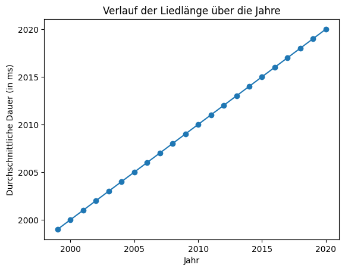

```python
jahresmittelwerte = liederdaten.groupby('year')['year'].mean() # <- Hier musst du noch die richtige Spalte auswählen
jahresmittelwerte.plot(kind='line', marker='o')
plt.xlabel('Jahr')
plt.ylabel('Durchschnittliche Dauer (in ms)')
plt.title('Verlauf der Liedlänge über die Jahre')
plt.show()
```

**Aufgabe:** Notiere in der nächsten Zelle deine Beobachtungen zu dem Diagramm.

-> Notiere hier deine Beobachtungen ...

**Aufgabe:** Finde nun heraus, ob sich die *popularity*, *tempo*, *energy* oder *danceability* über die letzten Jahre verändert haben.

a) Kopiere dir dazu den Code aus der vorherigen Zelle, in der das Liniendiagramm erstellt wurde. Füge ihn in der nächsten Zelle ein und ändere ihn entsprechend.

b) Notiere deine Beobachtungen in der übernächsten Zelle.

```python
# Füge hier den kopierten Code ein und verändere ihn
```

-> Notiere hier deine Beobachtungen ...

## Vergleiche zwischen den Genres

Wir haben bereits gesehen, wie wir zeitliche Trends analysieren können. Eine weitere Unterscheidung der Lieder kann nach dem Genre vorgenommen werden. Es stellt sich die Frage, ob sich Lieder verschiedener Genres unterschiedliche Werte in den Merkmalen haben.

In der nächsten Zelle werden Daten aus unserer Tabelle selektiert. Dies geschieht so, dass in der Spalte *genre* nach den Wörtern *pop* oder *rock* gesucht wird und nur die Zeilen, in denen das zutrifft, selektiert werden. Von diesen Teilbereichen werden anschließend jeweils Mittelwerte einer Spalte ausgerechnet und ausgegeben.

**Aufgabe:** Finde heraus, ob sich Lieder dieser beiden Genres in einem Merkmal unterscheiden. Lieder welches Genre sind beispielsweise lauter, schneller, energischer, ...? Notiere deine Ergebnisse in der übernächsten Zelle.

```python
pop_songs = liederdaten[liederdaten['genre'].str.contains('pop')]
rock_songs = liederdaten[liederdaten['genre'].str.contains('rock')]

merkmal = 'danceability'

print("Mittelwert für Pop:", pop_songs[merkmal].mean().round(3))
print("Mittelwert für Rock:", rock_songs[merkmal].mean().round(3))
```

```
Mittelwert für Pop: 0.65
Mittelwert für Rock: 0.55
```

-> Notiere hier deine Ergebnisse...

**Aufgabe:** Zwischen welchen Genres könnte es besonders große Unterschiede beim Tempo oder bei der Popularität geben? Kopiere den Code von oben in die nächste und ändere die Genres, nach denen gesucht wird. Schaue ob du große Unterschiede findest. Notiere deine Beobachtungen in der übernächsten Zelle.

```python
# Füge hier den kopierten Code ein und verändere ihn
```

-> Notiere hier deine Ergebnisse...

## Artists analysieren

In den Daten stecken auch Informationen über die Künstler/Künstlerinnen/Bands drin. Diese schauen wir uns nun genauer an.

**Aufgabe:** Finde heraus, welche drei Artists die meisten Lieder in unseren Daten haben.

*Tipp:* Wähle die Spalte 'artist' in unserer Tabelle aus und ergänze dahinter `.value_counts()`. Dies ist eine Methode, die berechnet, wie häufig ein Artist in der Spalte vorkommt.

```python
# Tipp: ....value_counts()
```

Wir können uns die Namen der Artists und die jeweilige Liederanzahl in einer neuen Tabelle speichern. Dies wird in der nächsten Zelle gemacht. Dazu wurden bereits die Mittelwerte für das Tempo berechnet. Das erlaubt uns anschließend zu analysieren, ob es Muster bei den Artists gibt, die schon häufiger Lieder veröffentlicht haben.

```python
artists = pd.DataFrame(liederdaten['artist'].unique(), columns=['Artist'])
artists['Liederanzahl'] = liederdaten['artist'].value_counts().sort_index(ascending=True).values
artists['Mittelwert'] = liederdaten.groupby('artist')['tempo'].mean().sort_index(ascending=True).values
artists
```

[output not shown]

654 rows × 3 columns

**Aufgabe:** Damit wir die Daten besser interpretieren können, erstelle ein Scatterplot für die neue Tabelle artists und die beiden Spalten *Liederanzahl* und *Mittelwert*.

*Tipp:* Am Ende des zweiten Notebooks hast du gelernt, wie Scatterplots erstellt werden. Schaue dir das nach Bedarf nochmal an.

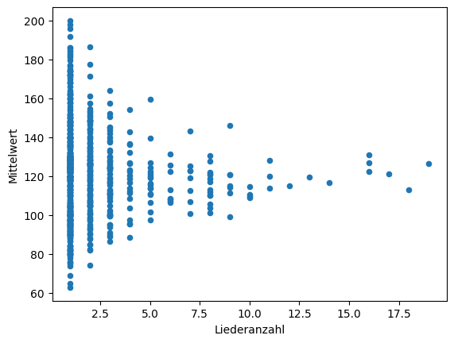

```python
artists.plot(kind="scatter", x="Liederanzahl", y="Mittelwert")
```

**Aufgabe:** Interpretiere das Diagramm. Kannst du etwas über die Künstlerinnen/Künstler oder Bands aussagen? Notiere deine Beobachtungen in der näcshten Zelle. Verändere anschließend die vorherige Code-Zelle, in der wir die Tabelle erstellt haben so, dass nicht tempo, sondern popularity betrachtet wird. Führe die Zelle mit dem Diagramm erneut aus und notiere deine Beobachtungen in der nächsten Zelle. Wiederhole dies für duration_ms, energy und danceability.

-> Notiere hier deine Beobachtungen...

**Aufgabe:** Darüber hinaus kann man auch die Veränderungen eines Artist im Verlauf der Jahre analysieren. In der nächsten Zelle findest du bereits einen Code, der dafür ein Diagramm erzeugt. Finde mithilfe des Codes heraus, was das Diagramm darstellt, und interpretiere es. Notiere deine Ergebnisse in der übernächsten Zelle.

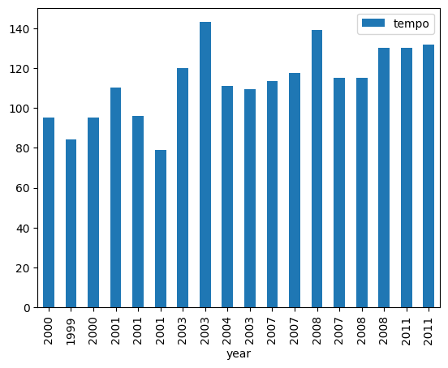

```python
liederdaten[liederdaten['artist'] == 'Britney Spears'].plot(x='year', y='tempo', kind='bar')
```

-> Notiere hier deine Beobachtungen...